# Melting Curves fro Phongroop 2023

Bob

2025-10-16

Here we extract melting curve data from Phongroop K, Rattanasrisomporn J, Tangtrongsup S, Rungsipipat A, Piewbang C, Techangamsuwan S. [High-resolution melting analysis for simultaneous detection and discrimination between wild-type and vaccine strains of feline calicivirus](https://pubmed.ncbi.nlm.nih.gov/37851857/). Vet Q. 2023 Dec;43(1):1-12. doi: 10.1080/01652176.2023.2272188. Epub 2023 Nov 1. PMID: 37851857; PMCID: PMC11003490. ,

Points on selected curves from Figure 1a were manually marked in [WebPlotDigitizer](https://automeris.io/wpd/?v=5_2) and saved to CSV files.

The x and y values in these files are scaled from 0 to 1; I apparently did not calibrate the graph correctly. For now, I have just re-scaled these values myself so that they match the figure.

## Figure 1a

### Melting curves

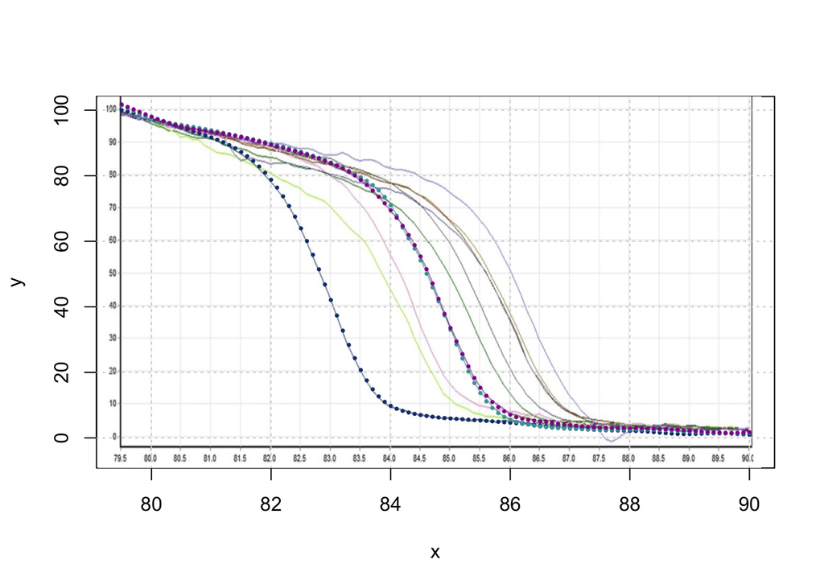

```r
# I extracted the colors from Figure 1 by pasting a screen
# shot of the legend into Inkscape, then using the color
# picker to get the exact RBG values for each strain.
color_legend <- c(
                        `Nobivac1_HCPCh`="#921c9a",
                        `FCV-TH/KP367` = "#a0fc4e",
                        `FCV-TH/KP135` = "#7f7f7f",
                        `FCV-TH/KP181` = "#aaaad3",
                        `FCV_GX01-13` = "#173e7b",
                        `FCV-TH/KP106` = "#ee86be",
                        `FCV-TH/KP80` = "#784415",
                        `FCV-TH/KP313` = "#2f6eba",
                        `FCV_UTCVM-H2` = "#49a2a3",
                        `FCV-TH/KP361` = "#367b21",
                        `FCV-TH/KP82` = "#9a833d"
)

fit_curve_data <- function(file_name){
    # Fit standardized melting curve to curve data.
    # Load datapoints from CSV file, rescale, fit spline,
    # take measurements at regularly spaced temperatures.
    # Param file_name: local path to a csv file containing
    #       unscaled x, y coordinates from WebPlotDigitizer.
    # Returns: dataframe with temperature and fluorescence columns.
    points_df <- read.csv(file.path('points_data', file_name),
                                                col.names=c("x", "y"))

    points_df$temperature <- 79.5 + points_df$x * (90.0 - 79.5)
    points_df$fluorescence <- 12 + points_df$y * (102.0 - 12) # fudge factors

    fit_ss <- with(points_df, smooth.spline(temperature, fluorescence, nknots = 20)) # try various numbers of knots

    std_data <- data.frame(temperature = seq(79.5, 90.0, by=0.1))
    std_data['fluorescence'] <- predict(fit_ss, std_data['temperature'])$y

    return(std_data)
}


library(png)
my_image <- readPNG("Phongroop_fig1a.png")

# Set up a plot area with no plot
plot(c(79.5, 90.0), c(-5, 100), type='n', main="", xlab="x", ylab="y")

# Draw the plot such that the image fills the plot box.
# lim <- par()
rasterImage(my_image,
            xleft=79.1, xright=90.2, # edges of the image in plot coordinates
            ybottom=-12, ytop=114)
grid()

data_files <- list.files('points_data') |>
    grep(".csv$", x=_, value=TRUE)

for (fn in data_files){
    points_df <- fit_curve_data(fn)
    strain_name <- fn |> gsub('.csv', '', x=_, fixed=TRUE)
    with(points_df, points(temperature, fluorescence, pch=20,
                                                 col=color_legend[strain_name],
                                                 cex=0.5))
}
```

### Amplicon sequences

The amplicon sequences are available from the [supplemental Materials](https://pmc.ncbi.nlm.nih.gov/articles/instance/11003490/bin/TVEQ_A_2272188_SM3964.docx). This is a Word document, but since the amplicon data is in a table, it was straightforward to save it as a CSV file. I edited the CSV slightly to make it easier to load.

Note that the melting curves were run on a subregion of the sequences in the table, defined by these primers:

- HRM_For: GGYGTGGAGGCGCGGWC
- HRM_Rev: CGTHAGCGCAGGTTGAGCACAT

which use these [IUPAC ambiguity codes](https://en.wikipedia.org/wiki/Nucleic_acid_notation): * Y: (pYrimidine) C or T * W: (Weak) A or T * H: (not G) A, C, or T

```r
amplicon_file <- "Phongroop_amplicon_sequences.csv"

amplicon_df <- read.csv(amplicon_file)

knitr::kable(amplicon_df)
```

| FCV.strain | Accession.no. | Sequence | Position | Base.pair |
| --- | --- | --- | --- | --- |
| Reference strain GX01-13 | KT970059 | TGGAACATTACAACAGCCAGTTCAATGGCGTGGAGGCGCGGTCCGATCAGATCAATATGAGTGATGGTACCGCCCTACACTGTGATGTGTTCGAAGTTTGAGCATGTGCTCAACCTGCGCTAACGTGCTAAAATACTATGATTGGGACCC | 5192 - 5341 | 150 |
| Reference strain UTCVM-H2 | AY560117 | TGGAGCATTACAACAGCCTATTCAATGGCGTGGAGGCGCGGACTGACCAGATCGATTCGAGTGGCATGGCCGCCCTACACTGTGATGTGTTCGAAGTTTGAGCATGTGCTCAACCTGCGCTAACGTGCTTAAATACTATGATTGGGATCC | 5208 - 5357 | 150 |
| Reference Strain SH/2014 | KT000003.1 | TGGAACATTACAACAGTCAGTTCAATGGTGTGGAGGCGCGGTCCGATCAGATCAAGATGAGTGATGGCACCGCCCTGCACTGTGATGTGTTCGAAGTTTGAACATGTGCTCAACCTGCGCTAACGTGCTTAAATATTATGATTGGGATCC | 5211-5360 | 150 |
| Reference Strain Jengo | DQ910793.1 | TGGAACATTACAACAGCCAGTTCAATGGTGTGGAGGCGCGGTCCGATCAGATCAGTATGAGTGATGGCACCGCCCTACACTGTGATGTGTTCGAAGTTTGAGCATGTGCTCAACCTGCGCTGACGTGCTTAAATACTATGATTGGGATCC | 5211-5360 | 150 |
| Reference strain FCV-Vac Nobivac® 1- HCPCh) | KU373057 | TGGAGCATTACAACAACCAGTTTAATGGTGTGGAGGCGCGGTCTGACCAGATCGATGCGAGTGGCATGACCGCCCTACACTGTGATGTGTTCGAAGTTTGAGCATGTGCTCAACCTGCGCTAACGTGCTTAAATATTACAATTGGGACCC | 5211 - 5360 | 150 |
| Wild-type Thai strain: FCV-TH/KP313 | OM982631 | TGGAATTCTATAATAGCCAATTTAATGGCGTGGAGGCGCGGACTGACCAGATCGGTGCGAGTGGCATGGCCGCCCTCCACTGTGATGTGGTCGAAGTTTGAGCATGTGCTCAACCTGCGCTAACGTGCTTAAACACTATGATTGGGACCC | 5214-5363a | 150 |